# CASA0005 第四周：Git、GitHub 与可复现 R Markdown

按[官方第 4 章](https://andrewmaclachlan.github.io/CASA0005repo/git-github-and-rmarkdown.html)顺序整理Git、GitHub 与 R Markdown。打开课程 `casa0005.Rproj`，代码按顺序运行；Knit 从头计算普通分析块；安装、导出与可选联网分支单独执行。

来源：MacLachlan、Dennett、Dooley；[CC BY-SA 4.0](https://creativecommons.org/licenses/by-sa/4.0/)。中文整理与适配经 AI 辅助，见改编范围；源版本 `0b19a3339034e3bd3de1e8246559d453301f07eb`。

## 4.4–4.5 Git 检查

以下命令在 Terminal 中运行。现有 `casa` 仓库无需在课程子目录重新初始化。

```bash
git --version
git status --short
git branch --show-current
git remote -v
git log -5 --oneline
git config --get user.name
git config --get user.email
```

## 检查提交内容

查看 Diff → 选择本次文件 → Commit → 核对远程与分支 → Push。Pull 前保留本地工作；GitHub 文件保存和老师表格登记分别处理。

```bash
# Terminal 中按选定文件提交。
git diff -- week04/practical-中文教程.Rmd
git diff --cached
```

## 4.6 R Markdown

YAML 设置文档输出；Markdown 写说明，chunk 放 R 代码。示例温度不是真实气候观测。

```r
example_data <- data.frame(month = month.abb[1:4], temperature = c(8, 9, 12, 15))
example_data
```

```
##   month temperature
## 1   Jan           8
## 2   Feb           9
## 3   Mar          12
## 4   Apr          15
```

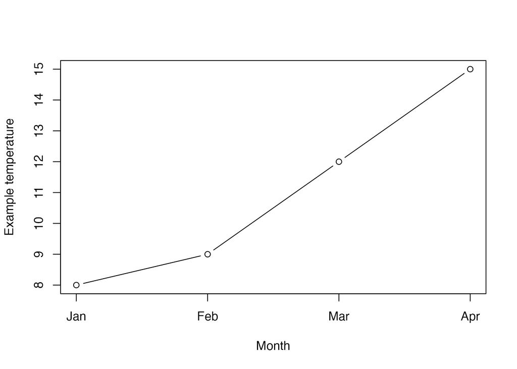

```r
plot(example_data$temperature, type = "b", xaxt = "n", xlab = "Month", ylab = "Example temperature")
axis(1, at = 1:4, labels = example_data$month)
```

```r
mean(example_data$temperature)
```

```
## [1] 11
```

## 代码块选项

`echo` 控制代码显示，`include` 控制整块输出，`eval` 控制执行；message、warning 仅控制提示显示。普通分析块从新会话 Knit。

[output not shown]

## Fork、分支与 Homework

Fork 创建账户下派生仓库，branch 是仓库内部工作线，PR 用于审阅合入。

GII 2010–2019 差值地图及 GitHub 分享见 homework.Rmd。课堂示例结果见 运行记录。阅读：R Markdown Guide 第 2 章与可复现研究文章。

## 资料链接

- [官方第 4 章](https://andrewmaclachlan.github.io/CASA0005repo/git-github-and-rmarkdown.html)
- [CC BY-SA 4.0](https://creativecommons.org/licenses/by-sa/4.0/)
- [复合指标时间序列](https://hdr.undp.org/data-center/documentation-and-downloads)